# Supervised Machine Learning Techniques Assignment I

#### model with sample dataset (50% of training dataset)

- because model entire training time is too long, use a small percentage of random samples of the data (50% of the training and testing)
- use the tuned hyperparameters

```python
# create sample dataset (50%)
train_smpl = train.sample(frac=0.5, random_state=1)
test_smpl = test.sample(frac=0.5, random_state=1)

train_hex = h2o.H2OFrame(train_smpl)
test_hex = h2o.H2OFrame(test_smpl)
```

```
Parse progress: |████████████████████████████████████████████████████████████████| (done) 100%
Parse progress: |████████████████████████████████████████████████████████████████| (done) 100%
```

```python
from h2o.estimators.deeplearning import H2ODeepLearningEstimator
dl_v2 = H2ODeepLearningEstimator(
    hidden = [200, 200, 200],
    input_dropout_ratio = 0.0,
    activation = 'RectifierWithDropout',
    sparse = True,
    epochs = 10,
    nfolds = 10,
    seed = 1234)

dl_v2.train(
    x=predictors,
    y=target,
    training_frame=train_hex)
```

```
deeplearning Model Build progress: |█████████████████████████████████████████████| (done) 100%
Model Details
=============
H2ODeepLearningEstimator :  Deep Learning
Model Key:  DeepLearning_model_python_1658864156156_4


Status of Neuron Layers: predicting loan_default, regression, gaussian distribution, Quadratic loss, 4,964,601 weights/biases, 57.3 MB, 281,404 training samples, mini-batch size 1
```

|  |  | layer | units | type | dropout | l1 | l2 | mean_rate | rate_rms | momentum | mean_weight | weight_rms | mean_bias | bias_rms |
| --- | --- | --- | --- | --- | --- | --- | --- | --- | --- | --- | --- | --- | --- | --- |
| 0 |  | 1 | 24419 | Input | 0.0 |  |  |  |  |  |  |  |  |  |
| 1 |  | 2 | 200 | RectifierDropout | 50.0 | 0.0 | 0.0 | 0.633516 | 0.444438 | 0.0 | 0.000164 | 0.009626 | 0.259391 | 0.270459 |
| 2 |  | 3 | 200 | RectifierDropout | 50.0 | 0.0 | 0.0 | 0.023958 | 0.020458 | 0.0 | -0.012911 | 0.08497 | 0.82964 | 0.161709 |
| 3 |  | 4 | 200 | RectifierDropout | 50.0 | 0.0 | 0.0 | 0.023425 | 0.024082 | 0.0 | -0.024096 | 0.078977 | 0.834942 | 0.100632 |
| 4 |  | 5 | 1 | Linear |  | 0.0 | 0.0 | 0.000454 | 0.000175 | 0.0 | -0.006329 | 0.036006 | 0.119844 | 0.0 |

```
ModelMetricsRegression: deeplearning
** Reported on train data. **

MSE: 0.14662921032203854
RMSE: 0.3829219376348638
MAE: 0.2815190943572911
RMSLE: 0.26598965680148307
Mean Residual Deviance: 0.14662921032203854

ModelMetricsRegression: deeplearning
** Reported on cross-validation data. **

MSE: 0.1479306947161302
RMSE: 0.38461759543230756
MAE: 0.3016459182659902
RMSLE: 0.27053484243159015
Mean Residual Deviance: 0.1479306947161302

Cross-Validation Metrics Summary:
```

|  |  | mean | sd | cv_1_valid | cv_2_valid | cv_3_valid | cv_4_valid | cv_5_valid | cv_6_valid | cv_7_valid | cv_8_valid | cv_9_valid | cv_10_valid |
| --- | --- | --- | --- | --- | --- | --- | --- | --- | --- | --- | --- | --- | --- |
| 0 | mae | 0.301671 | 0.010426 | 0.292081 | 0.306745 | 0.289892 | 0.301212 | 0.315502 | 0.284662 | 0.314896 | 0.298705 | 0.304209 | 0.308803 |
| 1 | mean_residual_deviance | 0.147936 | 0.003027 | 0.148420 | 0.147615 | 0.146049 | 0.148703 | 0.150813 | 0.141933 | 0.153551 | 0.146589 | 0.148238 | 0.147452 |
| 2 | mse | 0.147936 | 0.003027 | 0.148420 | 0.147615 | 0.146049 | 0.148703 | 0.150813 | 0.141933 | 0.153551 | 0.146589 | 0.148238 | 0.147452 |
| 3 | r2 | 0.049827 | 0.004135 | 0.049254 | 0.044086 | 0.053406 | 0.051039 | 0.051046 | 0.043395 | 0.053079 | 0.045622 | 0.055358 | 0.051980 |
| 4 | residual_deviance | 0.147936 | 0.003027 | 0.148420 | 0.147615 | 0.146049 | 0.148703 | 0.150813 | 0.141933 | 0.153551 | 0.146589 | 0.148238 | 0.147452 |
| 5 | rmse | 0.384607 | 0.003938 | 0.385253 | 0.384208 | 0.382164 | 0.385621 | 0.388346 | 0.376740 | 0.391856 | 0.382869 | 0.385017 | 0.383994 |
| 6 | rmsle | 0.270524 | 0.003843 | 0.267644 | 0.272349 | 0.266719 | 0.270228 | 0.275021 | 0.263507 | 0.275610 | 0.268915 | 0.272688 | 0.272562 |

```
Scoring History:
```

|  |  | timestamp | duration | training_speed | epochs | iterations | samples | training_rmse | training_deviance | training_mae | training_r2 |
| --- | --- | --- | --- | --- | --- | --- | --- | --- | --- | --- | --- |
| 0 |  | 2022-07-27 18:03:44 | 0.000 sec | None | 0.000000 | 0 | 0.0 | NaN | NaN | NaN | NaN |
| 1 |  | 2022-07-27 18:03:48 | 3:32:08.624 | 490 obs/sec | 0.068214 | 1 | 1910.0 | 0.398038 | 0.158435 | 0.251063 | -0.022562 |
| 2 |  | 2022-07-27 18:06:24 | 3:34:45.030 | 809 obs/sec | 4.165000 | 60 | 116620.0 | 0.384081 | 0.147518 | 0.279913 | 0.047894 |
| 3 |  | 2022-07-27 18:09:07 | 3:37:27.164 | 860 obs/sec | 8.941571 | 129 | 250364.0 | 0.383585 | 0.147137 | 0.310279 | 0.050351 |
| 4 |  | 2022-07-27 18:09:55 | 3:38:18.509 | 869 obs/sec | 10.050143 | 145 | 281404.0 | 0.382922 | 0.146629 | 0.281519 | 0.053631 |

```
Variable Importances:
```

|  | variable | relative_importance | scaled_importance | percentage |
| --- | --- | --- | --- | --- |
| 0 | AP003 | 1.000000 | 1.000000 | 0.000783 |
| 1 | MB005 | 0.639980 | 0.639980 | 0.000501 |
| 2 | AP006.android | 0.475785 | 0.475785 | 0.000372 |
| 3 | TD013 | 0.419285 | 0.419285 | 0.000328 |
| 4 | PA031 | 0.395894 | 0.395894 | 0.000310 |
| 5 | CR015 | 0.352736 | 0.352736 | 0.000276 |
| 6 | CR009 | 0.313733 | 0.313733 | 0.000246 |
| 7 | AP002 | 0.313468 | 0.313468 | 0.000245 |
| 8 | PA029 | 0.307268 | 0.307268 | 0.000241 |
| 9 | MB007.OPPO | 0.302927 | 0.302927 | 0.000237 |
| 10 | PA028 | 0.301344 | 0.301344 | 0.000236 |
| 11 | AP006.ios | 0.266914 | 0.266914 | 0.000209 |
| 12 | TD009 | 0.259411 | 0.259411 | 0.000203 |
| 13 | PA030 | 0.247851 | 0.247851 | 0.000194 |
| 14 | AP008 | 0.242509 | 0.242509 | 0.000190 |
| 15 | CR018 | 0.242188 | 0.242188 | 0.000190 |
| 16 | TD014 | 0.234097 | 0.234097 | 0.000183 |
| 17 | CR004 | 0.230414 | 0.230414 | 0.000180 |
| 18 | AP009 | 0.212568 | 0.212568 | 0.000166 |
| 19 | MB007.IPHONE9 | 0.208679 | 0.208679 | 0.000163 |

```
See the whole table with table.as_data_frame()
```

```python
createGains(dl_v2)
```

```
deeplearning prediction progress: |██████████████████████████████████████████████| (done) 100%
```

| decile | count | actual | non_actual | cum_count | cum_actual | cum_non_actual | percent_cum_actual | percent_cum_non_actual | if_random | lift | K_S | gain |
| --- | --- | --- | --- | --- | --- | --- | --- | --- | --- | --- | --- | --- |
| 0 | 1200 | 457 | 743 | 1200 | 457 | 743 | 0.19 | 0.08 | 235.7 | 1.94 | 11.0 | 38.08 |
| 1 | 1200 | 372 | 828 | 2400 | 829 | 1571 | 0.35 | 0.16 | 471.4 | 1.76 | 19.0 | 34.54 |
| 2 | 1200 | 295 | 905 | 3600 | 1124 | 2476 | 0.48 | 0.26 | 707.1 | 1.59 | 22.0 | 31.22 |
| 3 | 1200 | 259 | 941 | 4800 | 1383 | 3417 | 0.59 | 0.35 | 942.8 | 1.47 | 24.0 | 28.81 |
| 4 | 1200 | 262 | 938 | 6000 | 1645 | 4355 | 0.70 | 0.45 | 1178.5 | 1.40 | 25.0 | 27.42 |
| 5 | 1200 | 194 | 1006 | 7200 | 1839 | 5361 | 0.78 | 0.56 | 1414.2 | 1.30 | 22.0 | 25.54 |
| 6 | 1200 | 172 | 1028 | 8400 | 2011 | 6389 | 0.85 | 0.66 | 1649.9 | 1.22 | 19.0 | 23.94 |
| 7 | 1200 | 134 | 1066 | 9600 | 2145 | 7455 | 0.91 | 0.77 | 1885.6 | 1.14 | 14.0 | 22.34 |
| 8 | 1200 | 130 | 1070 | 10800 | 2275 | 8525 | 0.97 | 0.88 | 2121.3 | 1.07 | 9.0 | 21.06 |
| 9 | 1200 | 82 | 1118 | 12000 | 2357 | 9643 | 1.00 | 1.00 | 2357.0 | 1.00 | 0.0 | 19.64 |

The bank can choose to underwrite Segment 7 to 9 and avoid Segment 0 to 3.

```
deeplearning prediction progress: |██████████████████████████████████████████████| (done) 100%
```

```
   * ROC curve: The ROC curve plots the true positive rate vs. the false rositive sate

	  * The area under the curve (AUC): A value between 0.5 (random) and 1.0 (perfect), measuring the prediction accuracy

   * Recall (R) = The number of true positives / (the number of true positives + the number of false negatives)
```

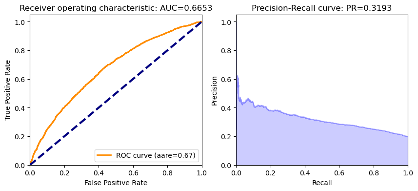

```python
ROC_AUC(dl_v2,test_hex,'loan_default')
```

#### Conclusion:

- Train the model using 50% of the training dataset, use all features and tuned hyperparameters
- The top three important features are AP003, MB005, AP006 - Android.
- The maximum lift is 1.94 and ROC curve has AUC score of 0.67.

## Summary

- Before ML modeling, prepare the predictor variables and split train and test by 70/30
- For start and find optimal model hyperparameters, model with a small sample dataset (10% of training dataset), and then create pipeline function for variable importance, gain table, and ROC curve to be used later on.
- Using the adjusted hyperparameters, run the GBM (Gradient Boosting Machine) model with the entire train dataset and validate the performance on the test dataset. The top three important features are MB007, TD013, AP003. The maximum lift is 1.87 and ROC curve has AUC score of 0.66.
- Using the adjusted hyperparameters, run the Deep Learning model with 50% of sample train dataset [*Because running the entire training dataset took too much time*] and validate the performance on the 50% test dataset. The top three important features are AP003, MB005, AP006 - Android. The maximum lift is 1.94 and the ROC curve has AUC score of 0.67.
- Deep Learning model has a slightly better performance than GBM model because it has higher AUC score and higher maximum lift score. However, it takes more time to learn and run the model.

Business Insights: